# Chapter C8 モノコック円筒の座屈強度

本章では、内圧の有無に関わらず、圧縮、曲げ、およびねじり荷重が単独または複合して作用する場合の円筒の座屈強度に関する情報を提供する。また、円錐筒の座屈強度に関する情報についても述べる。

## C8.1 はじめに

高速航空機、特にミサイルや宇宙機の登場以前は、補強材のない円筒（モノコック構造）の使用は非常に限られていた。しかし、宇宙時代の到来により、薄肉円筒はミサイルや宇宙構造物の設計において重要な存在となった。

平板シート構造の座屈強度の決定（章 A18 を参照）に十分であることが証明されている古典的な小たわみ理論は、薄肉円筒や曲面板パネルの座屈強度を決定するのには適していないことが判明している。なぜなら、その理論値は実験や試験結果と比較してあまりにも高い値を示すからである。

より最近の大たわみ理論は、実験結果とより近い一致を示しているが、初期不整（幾何学的欠陥）に関する事前の知見を必要とする。現在の理論的な限界の結果として、このような構造の強度設計は、主に理論的なパラメータを用いつつ、適用可能と思われる試験結果に対して最もフィットする実験的（ベストフィット）曲線に基づいている。

運用時および飛行中のミサイル構造は、引張、圧縮、曲げ、およびねじりの複合荷重系にさらされる。円筒は、内圧が加わっている場合もあれば、加わっていない場合もある。したがって、このような構造の設計には、単独または複合して作用する様々な荷重系における座屈強度の知見が必要となる。本章では、様々な応力条件下における円筒の座屈強度の試験データと設計曲線を示すことに限定する。

## C8.2 軸圧縮を受けるモノコック円筒の座屈

モノコック円筒という用語は、縦方向の縦通材（ストリンガー）や横方向の中間フレームが外板に取り付けられていない薄肉円筒を意味する。

多くの航空宇宙企業で使用されている設計手順に関する著者らの調査によると、文献1に示されている設計曲線が広く使用されていることがわかった。したがって、文献1からいくつかの設計資料を提示することが適切であると考えられる。

円筒は通常、その長さに基づいて以下の4つに分類される。

1. **短円筒 (Short Cylinders)**: 短円筒は平板柱（曲率半径が無限大の円筒）のように振る舞う傾向がある。これらは、平板の座屈に類似した正弦波の形で座屈（波形）を発生させる。端部の固定状態が大きな影響を及ぼす。
2. **中間または遷移長さの円筒 (Intermediate or Transition Length of Cylinders)**: 座屈は、正弦波とダイヤモンド形状が混合したパターンとなる。端部固定度と円筒長さの影響は限定的である。
3. **長円筒 (Long Cylinders)**: このような円筒はダイヤモンド型のパターンで座屈し、長さや端部条件はあまり重要ではない。
4. **極長円筒 (Very Long Cylinders)**: このような円筒は、全体的なオイラー座屈（柱としての不安定性）を起こすか、オイラー柱として機能する。

図 C8.1 は、軸圧縮荷重を受ける中間の長さの円筒の座屈破壊の写真を示している。

円筒の座屈強度の理論開発において、Donnell の名は顕著である。文献2から、Donnell の8階の微分方程式を使用することで、短円筒から長円筒の範囲における円筒の挙動に対する小たわみ理論解を得ることができる。Batdorf（文献3）による Donnell 方程式の解は、座屈係数 $K_c$ を用いて臨界応力を与える。単純支持された端部を持つ円筒の場合、この係数は以下の式で定義される。

$$K_c = \left[ \frac{(m^2 + \beta^2)^2}{m^2} \right] + \left[ \frac{12 Z^2
m^2}{\pi^4 (m^2 + \beta^2)^2} \right]$$
(C8.1)

ここで、 $m$ = 軸方向（縦方向）の半波長数

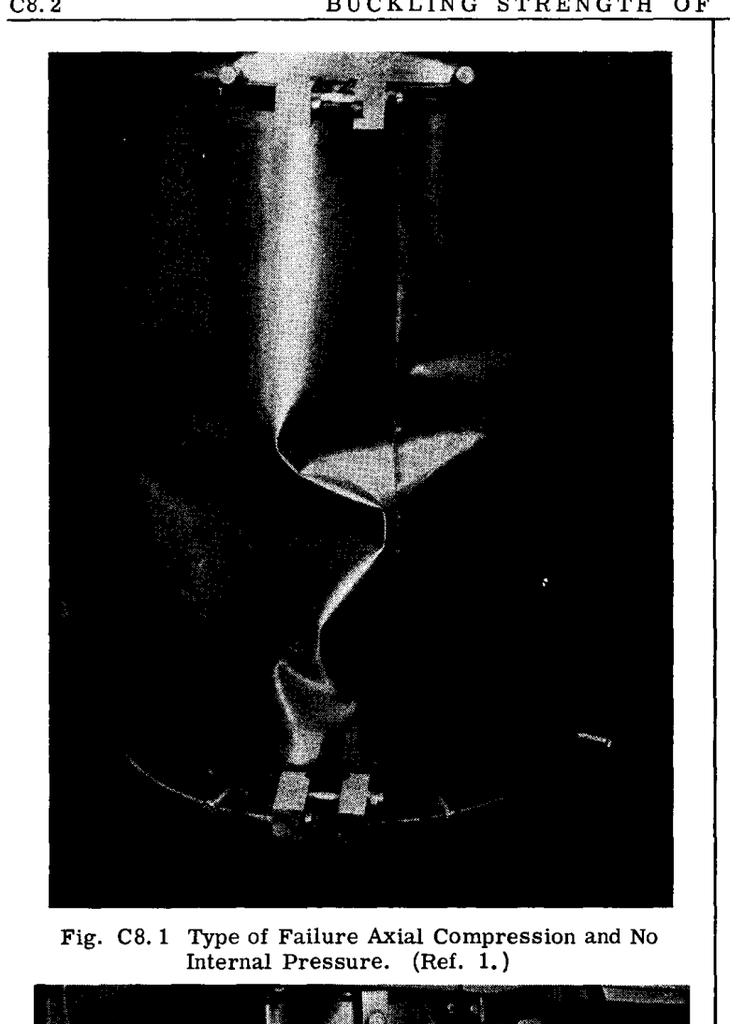

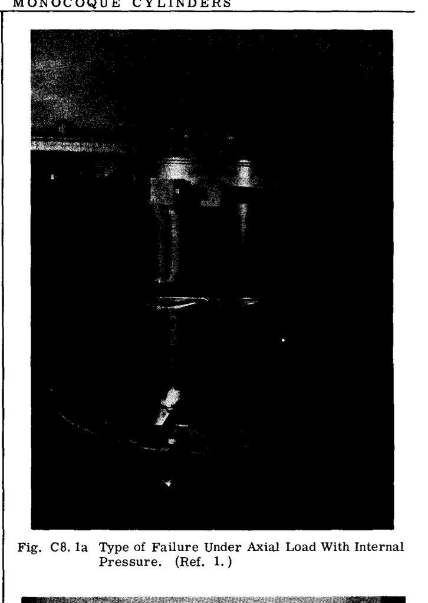

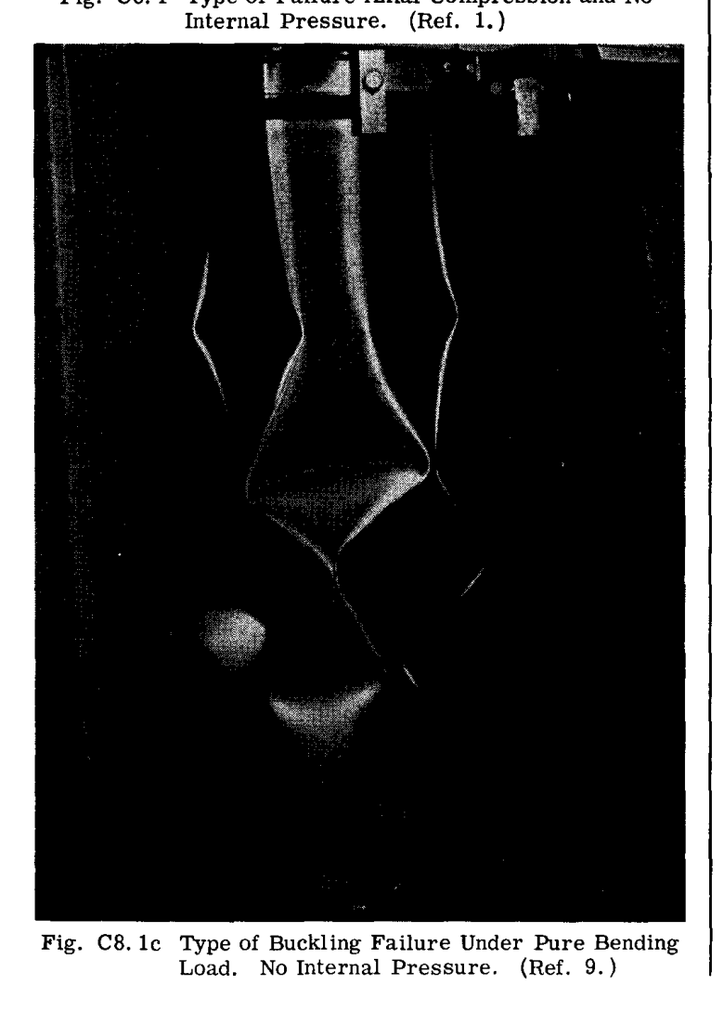

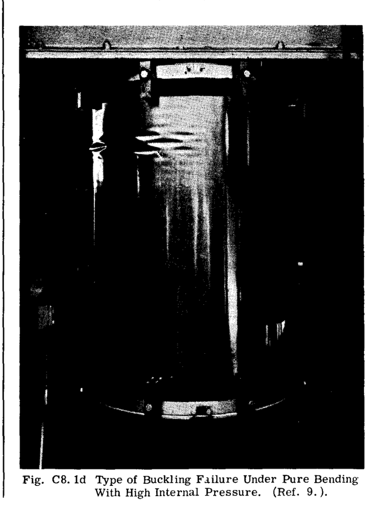

$$\beta = L/\lambda$$

$$\lambda = \text{周方向の座屈の半波長}$$

圧縮座屈応力は次式で与えられる。

ここで、 $t$ = 板厚、 $L$ = 円筒長さ、 $u$ = ポアソン比である。項 $\eta$ は塑性修正係数であり、弾性座屈の場合は 1.0 である。

パラメータ $(m^2 + \beta^2)^2/m^2$ に関して式(C8.1)を最小化すると、長円筒に対する臨界座屈係数は次の形になる。

$$K_c = (4\sqrt{3}/\pi^2) Z = 0.702 Z$$
(C8.3)

ここで、

式(C8.3)を式(C8.2)に代入すると、よく知られた古典的な式に単純化される。

$$F_{cr} = C E (t/r)$$
(C8.5)

ここで、 $u = 0.30$ に対して $C = 1 / [3 (1 - u^2)]^{1/2} = 0.605$ である。

遷移領域における単純支持端条件に対する座屈係数は、式(C8.1)において制限値 $\beta = 0$ および $m = 1$ を代入することによって決定できる。固定端を持つ円筒に対する同様の解は、単純支持された円筒の解から、平板領域および遷移領域でのみ逸脱する。

## C8.4 塑性修正

長円筒領域（ $L^2/rt > 100$ ）における円筒の塑性修正は、文献4から引用した 図 C8.9 の曲線によって与えられる。一般に、航空宇宙構造物における実用的な円筒のほとんどは、長円筒領域に該当する。

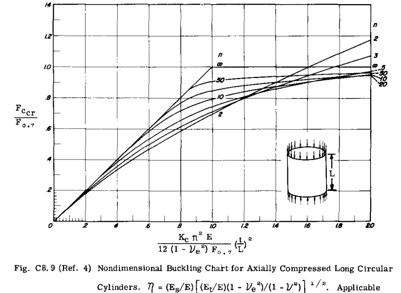

塑性修正係数

## C8.5 軸荷重と内圧を受けるモノコック円筒の座屈

長年行われてきた実験により、密閉された円筒に内圧を加えると、モノコック円筒の圧縮座屈強度が増加することが明確に示されている。ミサイル設計において軽量化は非常に重要であるため、内圧を利用したモノコック構造の使用は、ミサイルの構造設計において一般的な手法となっている。有名なアトラスミサイルは、内圧を利用したモノコック構造を採用した最初の例の一つである。

実際の試験強度と、一般に受け入れられている線形小たわみ理論による理論強度の間に大きな乖離がある主な理由は、幾何学的な初期不整とそれに伴う応力集中によるものである。高い内圧は、このような不整を滑らかにして完全な円筒に近づけるため、座屈強度は線形小たわみ理論で与えられる値に近づくはずである。しかし、加圧された円筒に対して入手可能な試験データの多くは、線形小たわみ理論から得られる値を下回っている。（加圧された円筒の座屈挙動については、図 C8.1a を参照。）

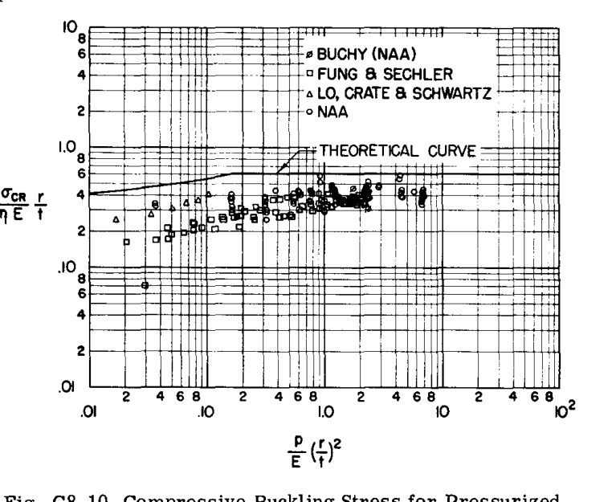

加圧円筒の座屈応力

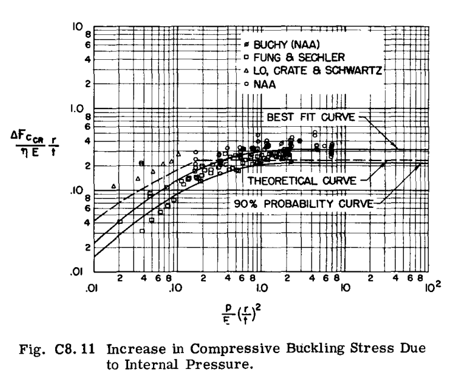

内圧による圧縮座屈応力の増加

## C8.6 純曲げを受けるモノコック円筒の座屈

飛行中および地上運用において、飛行体構造には曲げ作用を及ぼす力が加わるため、円筒の曲げ強度を知る必要がある。過去の設計実務では、2つのやや極端な仮定が使用されてきた。1つの設計仮定は、曲げ座屈応力の値を軸圧縮下の座屈応力の1.3倍とするものである。もう1つの仮定は、曲げ座屈応力を軸圧縮座屈応力と等しいと仮定するものである。最初の仮定は一部の設計者から非保守的とみなされることがあり、2番目の仮定は間違いなく幾分保守的である。

## C8.7 実験結果に基づく曲げの設計曲線

軸圧縮下の円筒に関する試験を行った同じ研究者ら（Suer、Harris、Skene、および Benjamin、文献1）は、純曲げを受けるモノコック円柱の座屈強度についても広範な調査を行っている（文献9を参照）。

Flügge（文献11）によって長円筒に対して最初に開発されたように、曲げにおける座屈応力は次のように表される。

$$F_{b_{cr}} = C_b E(t/r)$$
(C8.6)

Flüggeによって求められた曲げ座屈係数の理論値は、軸圧縮における対応する古典的な座屈係数 0.605 よりも約 30%高かった。

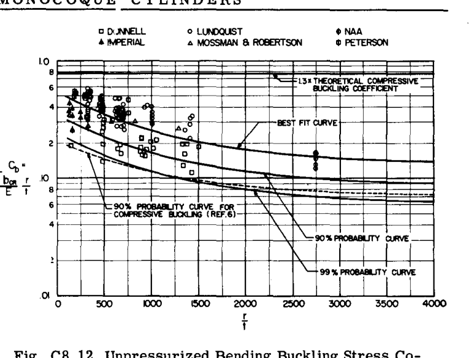

無加圧曲げ座屈係数

## C8.8 内圧を受ける円筒の曲げ座屈強度

内圧を受ける円筒の曲げ座屈強度に関する公表された情報は非常に限られており、これまでの理論的研究の状況はこの主題に関して多くの不明な点を残している。

文献9は、内圧を受ける円筒の曲げ試験の一連の結果を示している。図 C8.14 は、その公表された報告書から引用したものである。図 C8.14 では、実験データが座屈係数 $C_b$ に対する増加分 $\Delta C_{b_p}$ の観点からプロットされている。座屈応力係数の増加 $\Delta C_{b_p}$ は内圧の有益な効果を表している。座屈係数の全値は、無加圧円筒の座屈係数に、内圧による座屈係数の増加分を加算することによって得られる。データをプロットするために、まず各試験片の無加圧座屈係数を決定する必要があった。この目的のために、図 C8.12 の90%確率設計曲線が使用された。曲げを受ける円筒の安定性に対する横方向内圧の直接的な効果は、円形の記号で表される正味の軸応力がない試験片（バランスされた試験片）によって示されている。圧力パラメータの大きな値では、プレテンションをかけた試験片の $\Delta C_{b_p}$ の大きな増加によって、軸方向プレテンションの追加の効果が明確に示されている。三角形の記号で表される試験片は、バランスされた試験片のそれを上回っている。プレテンションをかけられた加圧円筒の座屈応力係数の増加の限界値は、圧力パラメータの非常に高い値において、直線 $\sigma_{cr} = pr/2t$ によって与えられる。

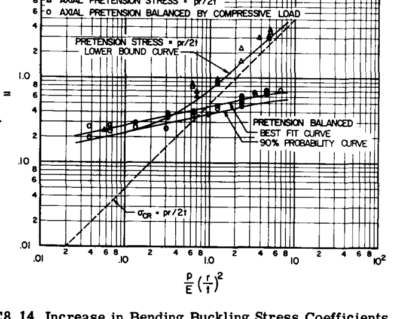

内圧による曲げ座屈係数の増加

## C8.9 外水圧を受けるモノコック円筒の座屈

このタイプの荷重下では、円筒シェルは縦方向圧縮応力の2倍に等しい周方向圧縮応力にさらされる。

この荷重タイプに対する座屈圧縮応力は、以下の式（文献12）によって与えられる。

座屈係数 $K_p$ の値は 図 C8.15 に示されている。式(C8.7)は、材料の比例限度応力以下の座屈応力に適用される。

## C8.10 外側ラジアル圧

内向きに作用するラジアル圧のみを受ける場合、発生する周方向圧縮応力は $f_c = pr/t$ である（ここで $p$ は圧力）。

このタイプの荷重下における座屈応力は、文献12より、

座屈係数 $K_y$ の値は 図 C8.16 に示されている。式(C8.8)は、材料の比例限度応力内の座屈応力に適用される。

## C8.11 純ねじりを受けるモノコック円筒の座屈

図 C8.17（文献12より）は、純ねじりを受ける薄肉円筒の試験結果を示している。図 C8.17 の理論曲線は、Batdorf、Stein、および Schildcrout の研究（文献15）によるものである。彼らの理論的研究は、Donnell の単一平衡方程式の修正形式（文献2）を利用し、Galerkin 法を用いて 図 C8.17 に示す曲線を得た。この理論曲線は試験結果を上回っているため、安全のために設計目的にはより低い曲線を使用する必要がある。図 C8.18 は、多くの航空宇宙企業の構造設計マニュアルに記載されている設計曲線を示している。

ねじり座屈応力は、次の式によって与えられる。

図 C8.18 はねじり座屈係数 $K_t$ の値を与え、比例限度応力以下の座屈に適用される。

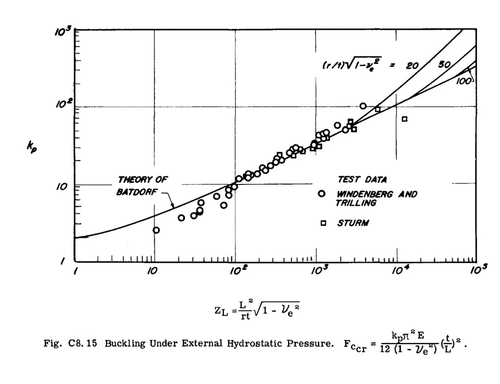

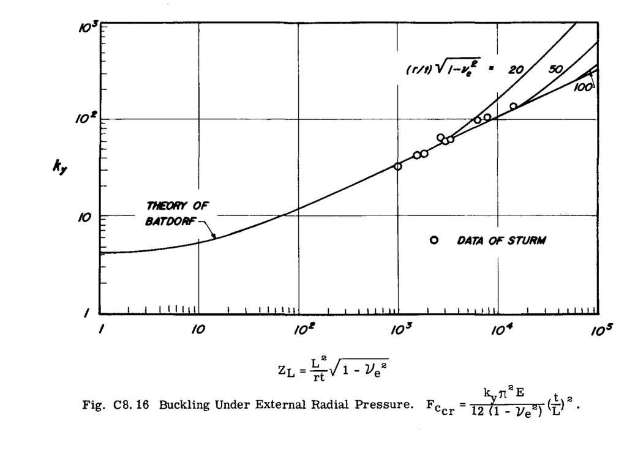

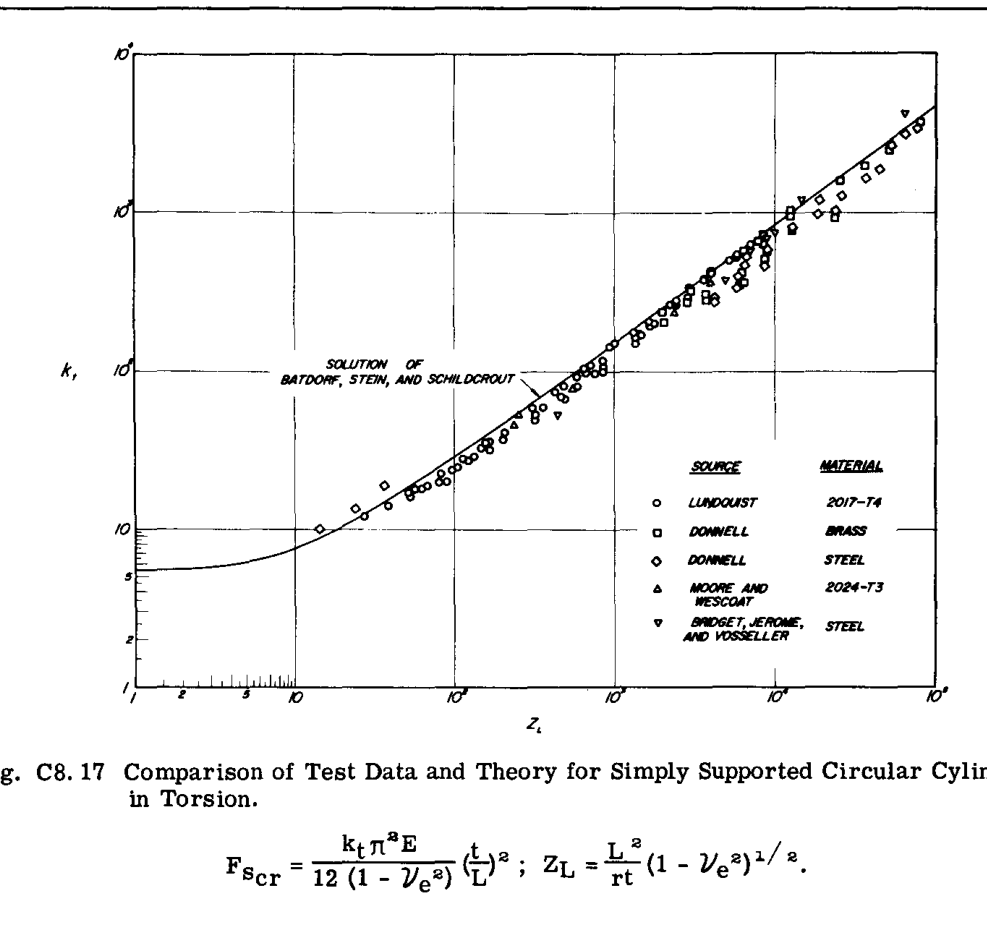

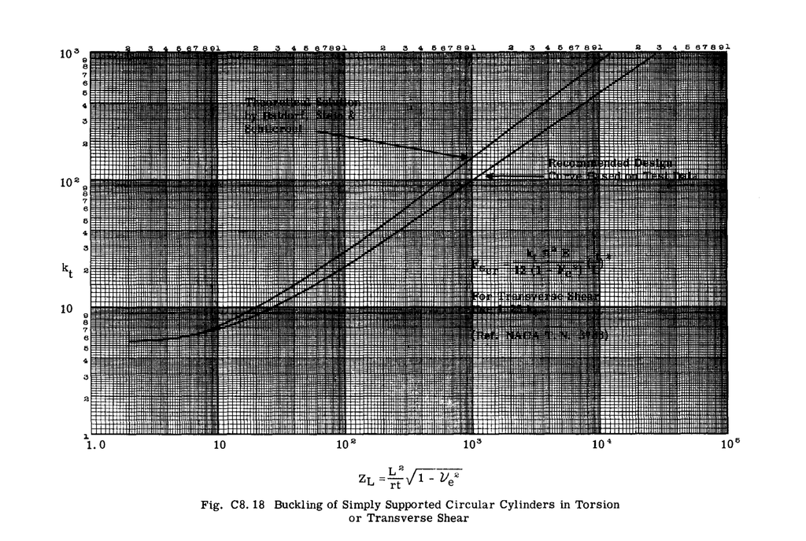